# Excess mortality

Final outputs for paper and appendix

# Result files

## Primary results from age adjusted models

```r
results_month <- merge_mort(bind_rows(
  read_rds("data/outputs_2021-11-23/Sweden_results_month.Rds"),
  read_rds("data/outputs_2021-11-24/Spain_results_month.Rds"),
  read_rds("data/outputs_2021-11-23/Switzerland_results_month.Rds")
)) %>%
  filter(Model == "Age Serfling (Stan, NB)") %>%
  mutate(Date = anytime::anydate(paste0(Year, "-", Month))) %>%
  arrange(Country, Year, Month) %>%
  relocate(c(n_eff, Rhat), .after = last_col()) %>%
  mutate(across(pred_total_deaths:excess_month_upper, round)) %>%
  relocate(Model, Pandemic, Country, Year, Month, Date)

results_year <- merge_mort(bind_rows(
  read_rds("data/outputs_2021-11-23/Sweden_results_year.Rds"),
  read_rds("data/outputs_2021-11-24/Spain_results_year.Rds"),
  read_rds("data/outputs_2021-11-23/Switzerland_results_year.Rds")
)) %>%
  filter(Model == "Age Serfling (Stan, NB)") %>%
  arrange(Country, Year) %>%
  mutate(across(yearly_pred_total_deaths:yearly_excess_total_deaths_upper, round)) %>%
  relocate(Model, Pandemic)

results_age <- merge_mort(bind_rows(
  read_rds("data/outputs_2021-11-23/Sweden_results_age.Rds"),
  read_rds("data/outputs_2021-11-24/Spain_results_age.Rds"),
  read_rds("data/outputs_2021-11-23/Switzerland_results_age.Rds")
)) %>%
  filter(Model == "Age Serfling (Stan, NB)") %>%
  arrange(Country, Year) %>%
  mutate(across(pred_grouped_deaths:excess_grouped_lifelost70_upper, round)) %>%
  relocate(Model, Pandemic, Country, Year, Age_cat, Deaths)
```

## Sensitivity analysis using Bayesian NB model, unadjusted models

```r
results_year_global <- merge_mort(bind_rows(
  read_rds("data/outputs_2021-11-23/Sweden_results_year.Rds"),
  read_rds("data/outputs_2021-11-24/Spain_results_year.Rds"),
  read_rds("data/outputs_2021-11-23/Switzerland_results_year.Rds")
)) %>%
  filter(Model == "Global Serfling (Stan, NB)") %>%
  arrange(Country, Year) %>%
  mutate(across(yearly_pred_total_deaths:yearly_excess_total_deaths_upper, round)) %>%
  relocate(Model, Pandemic)
```

## Sensitivity analysis using frequentist Poisson model, unadjusted for age

```r
results_month_boot <- read_rds("data/outputs_2021-11-18/All_results_month.Rds") %>%
  mutate(Date = anytime::anydate(paste0(Year, "-", Month))) %>%
  arrange(Country, Year, Month) %>%
  mutate(across(pred:excess_month_lower, round)) %>%
  mutate(Model = "Global Serfling (bootstrap)") %>%
  relocate(Model, Country, Year, Month, Date)
```

## Sensitivity analysis using alternative longer (7 days) time window

```r
results_year_last_7_notrim <- merge_mort(bind_rows(
  read_rds("data/outputs_2021-12-01/Sweden_results_year_last_7_notrim.Rds"),
  read_rds("data/outputs_2021-12-01/Spain_results_year_last_7_notrim.Rds"),
  read_rds("data/outputs_2021-12-01/Switzerland_results_year_last_7_notrim.Rds")
)) %>%
  filter(Model == "Age Serfling (Stan, NB, last 7 no trim)") %>%
  arrange(Country, Year) %>%
  mutate(across(yearly_pred_total_deaths:yearly_excess_total_deaths_upper, round)) %>%
  relocate(Model, Pandemic)
```

## Sensitivity analysis using alternative time window & min/max selection

```r
results_year_last_7_trim <- merge_mort(bind_rows(
  read_rds("data/outputs_2021-11-23/Sweden_results_year_last_7_trim.Rds"),
  read_rds("data/outputs_2021-11-24/Spain_results_year_last_7_trim.Rds"),
  read_rds("data/outputs_2021-11-23/Switzerland_results_year_last_7_trim.Rds")
)) %>%
  filter(Model == "Age Serfling (Stan, NB, last 7)") %>%
  arrange(Country, Year) %>%
  mutate(across(yearly_pred_total_deaths:yearly_excess_total_deaths_upper, round)) %>%
  relocate(Model, Pandemic)
```

## Sensitivity analysis for including effects of pandemics

```r
results_month_pand <- merge_mort(bind_rows(
  read_rds("data/outputs_2021-11-23/Sweden_results_month_pand.Rds"),
  read_rds("data/outputs_2021-11-24/Spain_results_month_pand.Rds"),
  read_rds("data/outputs_2021-11-23/Switzerland_results_month_pand.Rds")
)) %>%
  filter(Model == "Age Serfling (Stan, NB, pandemic)") %>%
  mutate(Date = anytime::anydate(paste0(Year, "-", Month))) %>%
  relocate(c(n_eff, Rhat), .after = last_col()) %>%
  arrange(Country, Year, Month) %>%
  mutate(across(pred_total_deaths:excess_month_upper, round)) %>%
  relocate(Model, Pandemic, Country, Year, Month, Date)
```

## Population

```r
pops <- read_rds("data/deaths_monthly.Rds") %>%
  filter(Month == 1) %>%
  select(Year, Country, Population_obs) %>%
  rename(Population = Population_obs)
```

## COVID-19 cases

```r
covid_cases_deaths_jh <- read_rds("data/covid_cases_deaths_jh.Rds")
```

## Yearly deaths by age

```r
deaths_yearly_age_sex <- read_rds("data/deaths_yearly_age_sex.Rds")
```

# Paper outputs

## Table 1

Characteristics of the 4 Deadliest Pandemics of the Past 140 Years in Switzerland, Sweden, and Spain, by Calendar Year.

| Calendar Year and Country | Population, n | Deaths From All Causes, n Count | Deaths From All Causes, n Expected | COVID-19 Deaths, n$^*$ Count$^†$ |
| --- | --- | --- | --- | --- |
| **1890** |  |  |  |  |
| Switzerland | 2 949 868 | 61 805 | 55 700 to 61 100 | – |
| Sweden | 4 775 819 | 81 824 | 69 300 to 77 000 | – |
| **1918** |  |  |  |  |
| Switzerland | 3 878 360 | 75 034 | 47 600 to 53 100 | – |
| Sweden | 5 802 022 | 104 591 | 73 500 to 84 000 | – |
| Spain | 21 300 235 | 695 758 | 429 700 to 480 000 | – |
| **1957** |  |  |  |  |
| Switzerland | 5 097 745 | 51 066 | 49 300 to 54 700 | – |
| Sweden | 7 341 017 | 73 132 | 67 800 to 73 000 | – |
| Spain | 29 445 865 | 293 502 | 264 700 to 296 200 | – |
| **2020** |  |  |  |  |
| Switzerland | 8 605 965 | 76 195 | 64 700 to 70 900 | 7 873 |
| Sweden | 10 327 496 | 97 870 | 86 900 to 93 700 | 8 727 |
| Spain | 47 332 613 | 492 930 | 400 500 to 441 000 | 50 837 |
| **2021$^‡$** |  |  |  |  |
| Switzerland | 8 670 302 | 34 619 | 33 700 to 37 700 | 2 900 |
| Sweden | 10 379 295 | – | – | 5 903 |
| Spain | 47 394 223 | 234 994 | 210 300 to 238 400 | 30 046 |

* Data are from the Johns Hopkins Coronavirus Resource Center  
† Model-predicted number of deaths due to all causes from the 5 preceding years (95% credible interval, rounded to the next 100).  
‡ Only the first 6 months of the year were included in the analyses. No age-specific data were available from Sweden for this period.

## Table 2

Model-Based Estimates of Absolute Excess Deaths, Absolute Excess Deaths Scaled by Population, Relative Excess Deaths (Compared With Expected Number of Deaths), and Number of Life-Years Lost Until Age 70 Years.

[output not shown]

* Absolute number of excess deaths scaled by country population.  
† Absolute number of excess deaths scaled by the number of expected deaths.  
‡ Sum of life years lost until the age of 70 in thousands.  
<sup>§</sup> Based on 8000 posterior samples, the probability that the relative number of deaths in 2020 was larger than in 1957 is 100% for Switzerland, 94.3% for Sweden, and 99.9% for Spain.

## Figure 1

Yearly excess per population.

**Note:** *the scales of Y axes vary by country!*

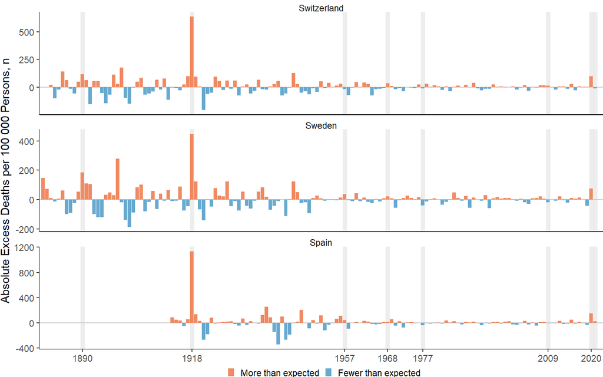

## Figure 2

Zooming to pandemics to explore absolute excess with CrI.

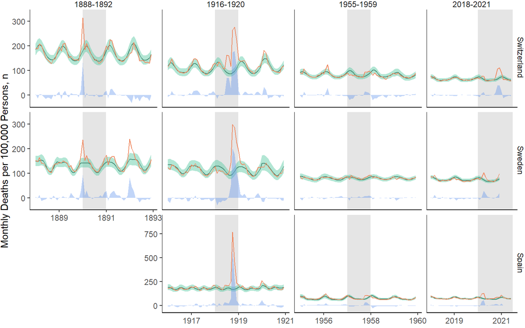

## Figure 3

Age differences across major pandemics (per population).

**Note:** *Excludes category `[90,120]` in pandemic years `1890` & `1918` due to small number of deaths in these age groups resulting in very large CrI.*

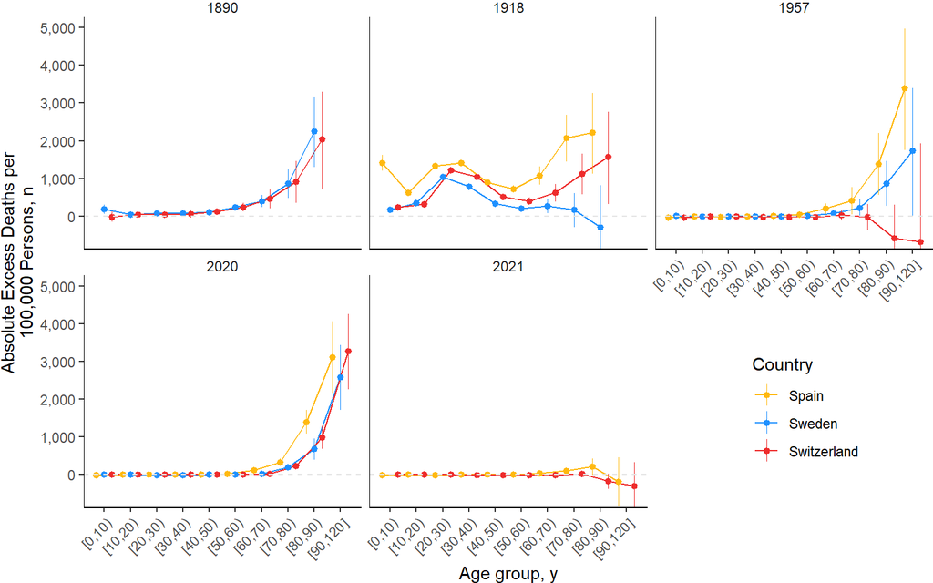

# Appendix

## Table S1

Comparing main estimates (`Age Serfling (Stan, NB)`) of excess from alternative methods:

- `Global Serfling (bootstrap)`
- `Global Serfling (Stan, NB)`
- `Age Serfling with alternative 7 day time window and min/max trim (Stan, NB)`
- `Age Serfling with alternative 7 day time window and no trim (Stan, NB)`

```r
pandemic_years <- c(1890, 1918, 1957, 2020, 2021)

table_s1 <-

  bind_rows(

    # baseline, ie. reported in paper `Age Serfling (Stan, NB)`
    results_year  %>%
      mutate(Model = "m0") %>%
      select(Model, Country, Year,
             starts_with("yearly_excess_total_deaths")),

    # Global Serfling (bootstrap)
    # simply summed from monthly values to obtain year
    # !without CI for yearly!
    results_month_boot %>%
      mutate(excess = Deaths - pred) %>%
      group_by(Model, Country, Year) %>%
      summarise(yearly_excess_total_deaths = sum(excess)) %>%
      ungroup() %>%
      mutate(Model = "m1"),

    # Global Serfling (Stan, NB) without age
    results_year_global  %>%
      mutate(Model = "m2") %>%
      select(Model, Country, Year,
             starts_with("yearly_excess_total_deaths")),

    # Age Serfling with alternative time window & min/max trim (Stan, NB)
    results_year_last_7_notrim  %>%
      mutate(Model = "m3") %>%
      select(Model, Country, Year,
             starts_with("yearly_excess_total_deaths")),

    # Age Serfling with alternative time window (Stan, NB)
    results_year_last_7_trim  %>%
      mutate(Model = "m4") %>%
      select(Model, Country, Year,
             starts_with("yearly_excess_total_deaths"))

  ) %>%
  filter(Year %in% c(pandemic_years, pandemic_years - 1, pandemic_years + 1)) %>%
  arrange(desc(Country), Year, Model) %>%
  pivot_wider(names_from = Model,
              values_from = starts_with("yearly_excess"),
              names_sort = FALSE) %>%
  relocate(Country, Year,
           yearly_excess_total_deaths_m0,
           yearly_excess_total_deaths_lower_m0,
           yearly_excess_total_deaths_upper_m0,
           yearly_excess_total_deaths_m1,
           yearly_excess_total_deaths_lower_m1,
           yearly_excess_total_deaths_upper_m1,
           yearly_excess_total_deaths_m2,
           yearly_excess_total_deaths_lower_m2,
           yearly_excess_total_deaths_upper_m2,
           yearly_excess_total_deaths_m3,
           yearly_excess_total_deaths_lower_m3,
           yearly_excess_total_deaths_upper_m3,
           yearly_excess_total_deaths_m4,
           yearly_excess_total_deaths_lower_m4,
           yearly_excess_total_deaths_upper_m4
  ) %>%
  select(-yearly_excess_total_deaths_lower_m1, -yearly_excess_total_deaths_upper_m1) %>%

  mutate(
    yearly_excess_total_deaths_m0 = number(yearly_excess_total_deaths_m0,
                                           accuracy = 5L, big.mark = " "),
    yearly_excess_total_deaths_m1 = number(yearly_excess_total_deaths_m1,
                                           accuracy = 5L, big.mark = " "),
    yearly_excess_total_deaths_m2 = number(yearly_excess_total_deaths_m2,
                                           accuracy = 5L, big.mark = " "),
    yearly_excess_total_deaths_m3 = number(yearly_excess_total_deaths_m3,
                                           accuracy = 5L, big.mark = " "),
    yearly_excess_total_deaths_m4 = number(yearly_excess_total_deaths_m4,
                                           accuracy = 5L, big.mark = " ")
  ) %>%

  mutate(
    yearly_excess_total_deaths_m0_cri = str_c("(",
                                              number(yearly_excess_total_deaths_lower_m0,
                                                     accuracy = 5L, big.mark = " "),
                                              " to ",
                                              number(yearly_excess_total_deaths_upper_m0,
                                                     accuracy = 5L, big.mark = " "),
                                              ")")
  ) %>%
  relocate(yearly_excess_total_deaths_m0_cri,
           .after = yearly_excess_total_deaths_m0) %>%
  select(-yearly_excess_total_deaths_lower_m0,
         -yearly_excess_total_deaths_upper_m0) %>%

  mutate(
    yearly_excess_total_deaths_m2_cri = str_c("(",
                                              number(yearly_excess_total_deaths_lower_m2,
                                                     accuracy = 5L, big.mark = " "),
                                              " to ",
                                              number(yearly_excess_total_deaths_upper_m2,
                                                     accuracy = 5L, big.mark = " "),
                                              ")")
  ) %>%
  relocate(yearly_excess_total_deaths_m2_cri,
           .after = yearly_excess_total_deaths_m2) %>%
  select(-yearly_excess_total_deaths_lower_m2,
         -yearly_excess_total_deaths_upper_m2) %>%

  mutate(
    yearly_excess_total_deaths_m3_cri = str_c("(",
                                              number(yearly_excess_total_deaths_lower_m3,
                                                     accuracy = 5L, big.mark = " "),
                                              " to ",
                                              number(yearly_excess_total_deaths_upper_m3,
                                                     accuracy = 5L, big.mark = " "),
                                              ")")
  ) %>%
  relocate(yearly_excess_total_deaths_m3_cri, .after = yearly_excess_total_deaths_m3) %>%
  select(-yearly_excess_total_deaths_lower_m3, -yearly_excess_total_deaths_upper_m3) %>%

  mutate(
    yearly_excess_total_deaths_m4_cri = str_c("(",
                                              number(yearly_excess_total_deaths_lower_m4,
                                                     accuracy = 5L, big.mark = " "),
                                              " to ",
                                              number(yearly_excess_total_deaths_upper_m4,
                                                     accuracy = 5L, big.mark = " "),
                                              ")")
  ) %>%
  relocate(yearly_excess_total_deaths_m4_cri, .after = yearly_excess_total_deaths_m4) %>%
  select(-yearly_excess_total_deaths_lower_m4, -yearly_excess_total_deaths_upper_m4) %>%

  mutate(across(yearly_excess_total_deaths_m0:yearly_excess_total_deaths_m4_cri,
                ~replace(., is.na(.), "--")))
```

[output not shown]

* Serfling, Poisson, unadjusted for age  
† Serfling, NB, unadjusted for age  
‡ Serfling, NB, age adjusted, alternative time window, no trim  
<sup>§</sup> Serfling, NB, age adjusted, alternative time window, trim

## Figure S1

Yearly estimates of excess

### Absolute

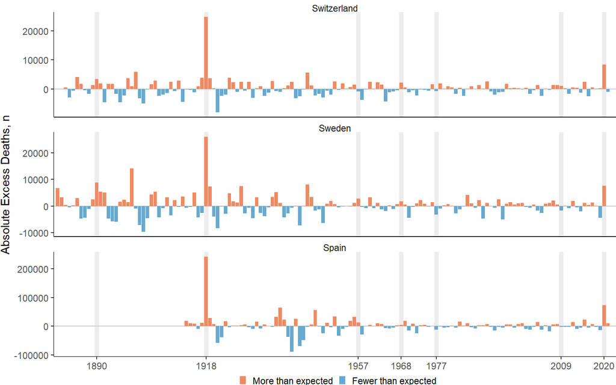

### Percentage

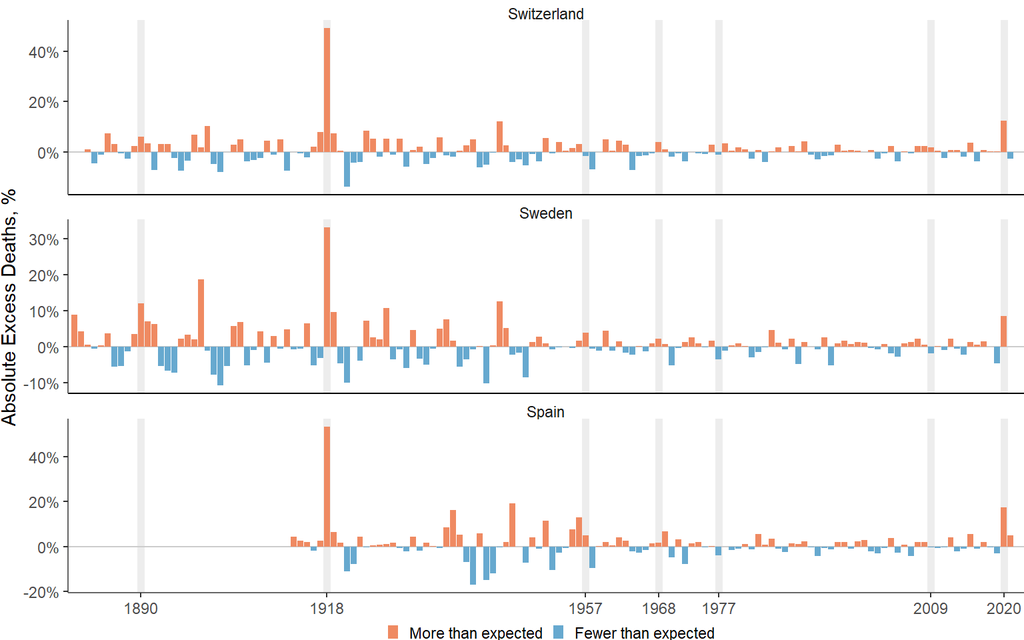

## Figure S2

Monthly estimates of excess

### Absolute

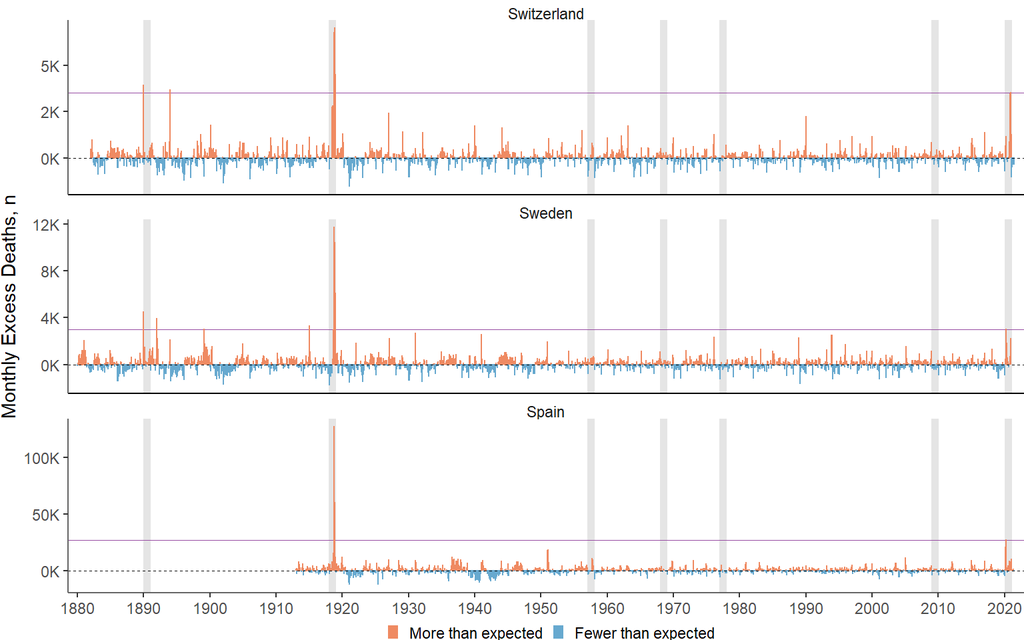

### Relative

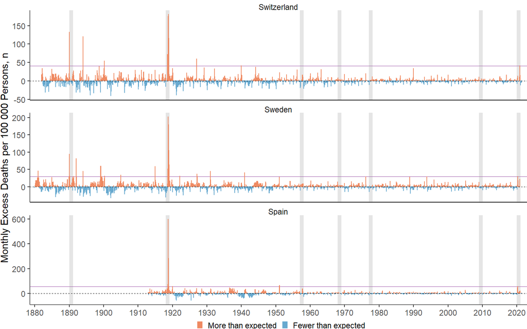

### Percentage

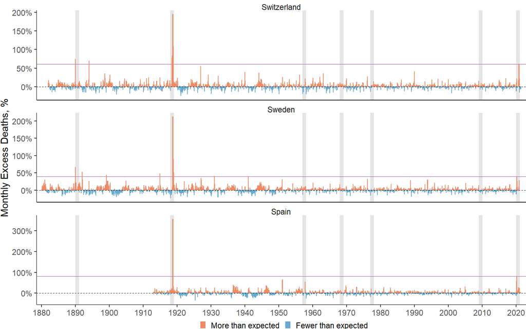

## Figure S3

Zooming to pandemics to explore excess

### Absolute

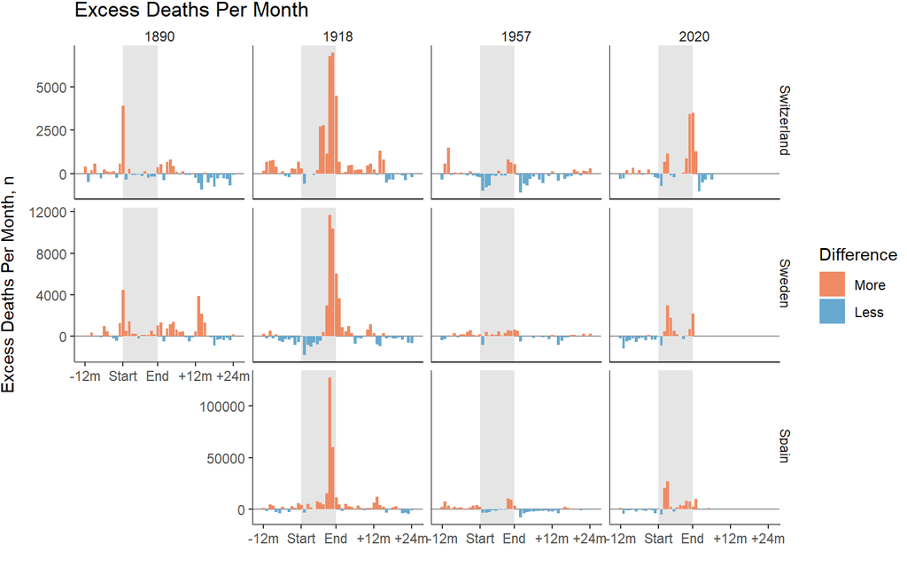

### Percentage

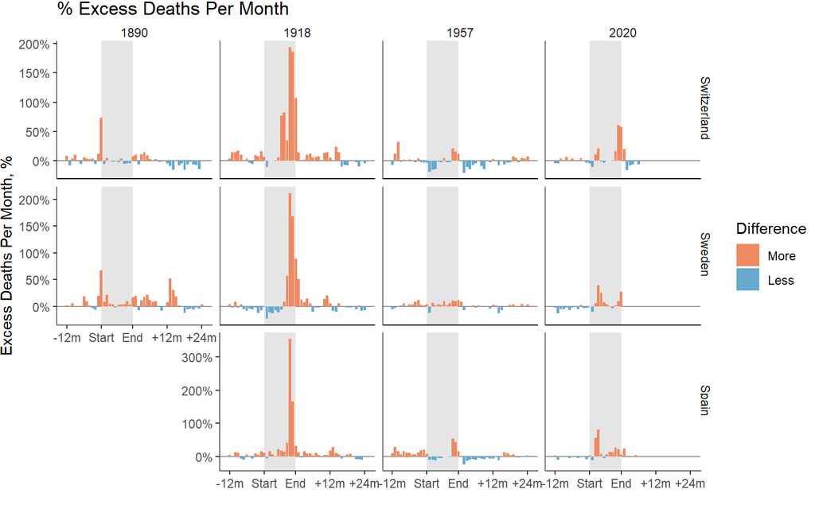

## Figure S4

Age differences across major pandemics - with %s

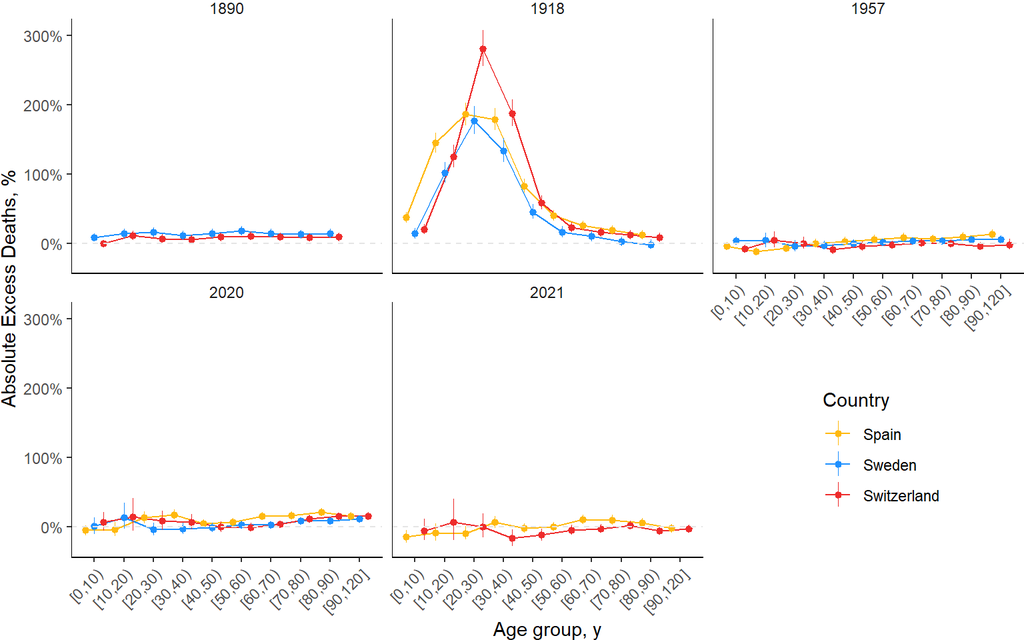

## Figure S5

Different age profiles of excess deaths across two pandemics and three countries.

### Percentage

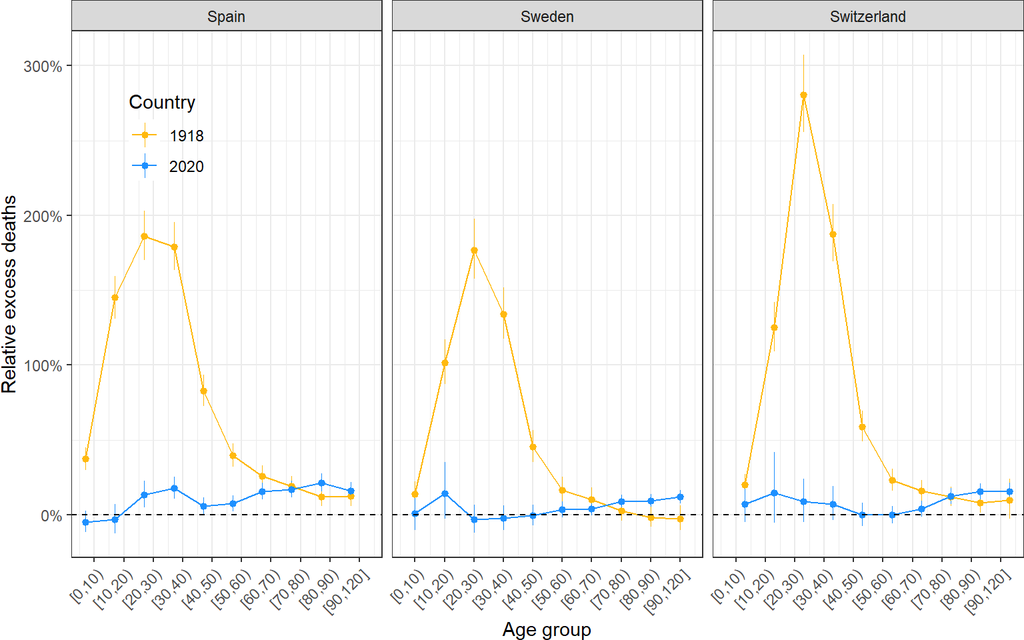

### Per population

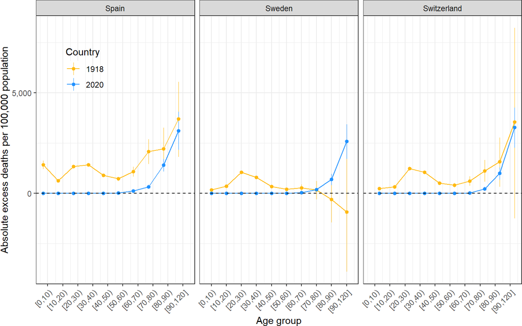

## Figure S6

Impact of extremes: using 1918 pandemic as an example of impact on estimates from 1919 - 1923.  
Estimates with extreme year (blue) and without (red).  
Converge after 5 year smoothing window stops having effect (ie. in 1924).

### Figure 1918-1925

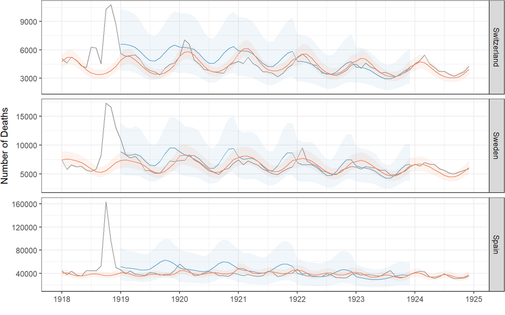

### Table 1919

Using 1918 pandemic as an example of impact on estimates from 1919.

[output not shown]

### Figure 2020-21

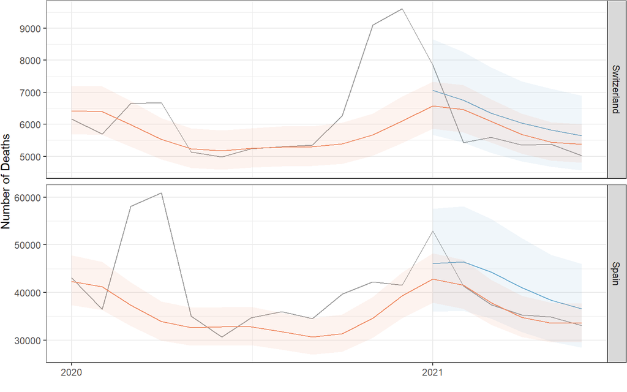

### Table 2021

[output not shown]

## Pandemic compared to last year

**2021 not included yet since not a full year!**

### Absolute

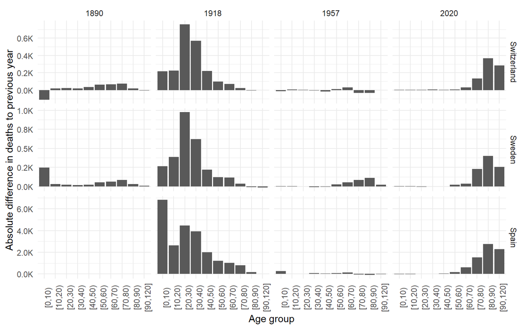

### Relative

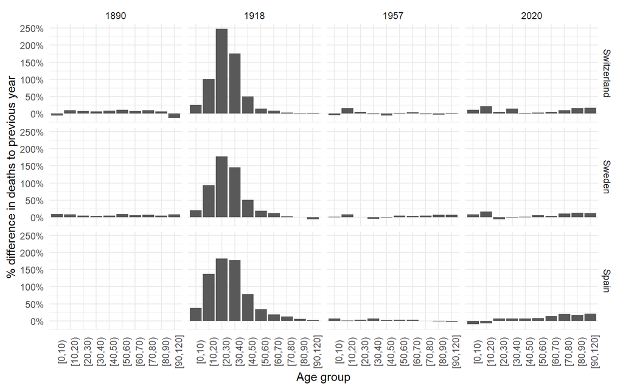

## Comparing to BfS estimates

Data from BfS prepared in `03`. No CI included in comparisons since different age groups are used!

| Year | Excess_BfS | Excess_modelled | Difference |
| --- | --- | --- | --- |
| 2010 | 696 | 264 | -432 |
| 2011 | -672 | -1640 | -968 |
| 2012 | 1436 | 452 | -984 |
| 2013 | 964 | 373 | -591 |
| 2014 | -1528 | -1297 | 231 |
| 2015 | 2463 | 2399 | -64 |
| 2016 | -1994 | -2517 | -523 |
| 2017 | 166 | 494 | 328 |
| 2018 | -76 | 122 | 198 |
| 2019 | 539 | 163 | -376 |
| 2020 | 7950 | 8429 | 479 |
| 2021 | -130 | -1002 | -872 |

# Model diagnostics

## Rhat

Check that all values <1.1

```r
summary(results_month[results_month$Model != "Global Serfling", ]$Rhat)
```

```
   Min. 1st Qu.  Median    Mean 3rd Qu.    Max.
 0.9996  1.0000  1.0002  1.0002  1.0004  1.0017
```

## ESS

Check that all effective sample sizes are large

```r
summary(results_month[results_month$Model != "Global Serfling", ]$n_eff)
```

```
   Min. 1st Qu.  Median    Mean 3rd Qu.    Max.
   4813    6789    7076    7057    7346    8275
```

## Model agreement

Example of 2020

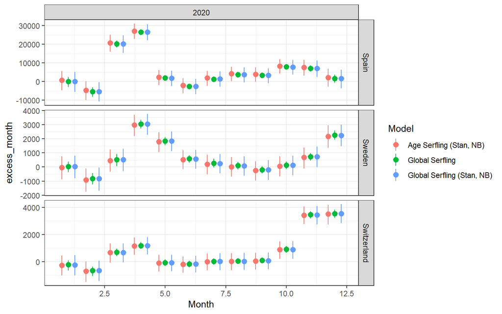

And 1918

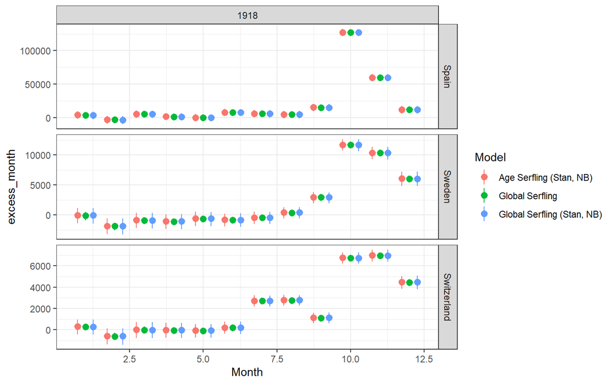

## Check age

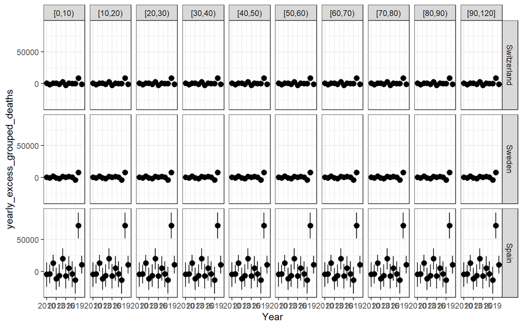

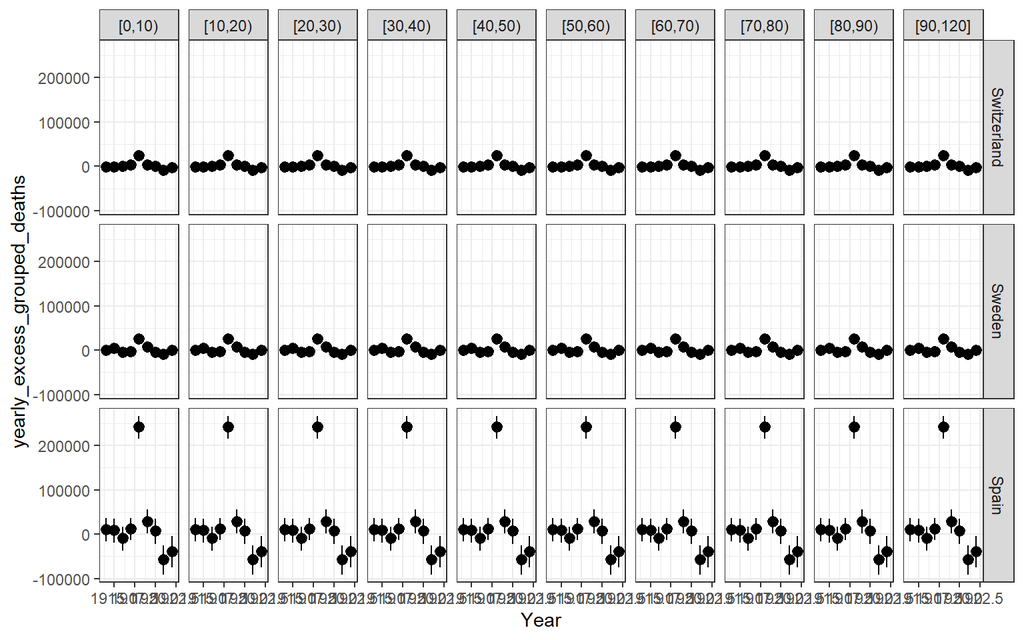

To cite R in publications use:

R Core Team (2021). *R: A Language and Environment for Statistical Computing*. R Foundation for Statistical Computing, Vienna, Austria. https://www.R-project.org/.

To cite the `ggplot2` package in publications use:

Wickham H (2016). *ggplot2: Elegant Graphics for Data Analysis*. Springer-Verlag New York. ISBN 978-3-319-24277-4, https://ggplot2.tidyverse.org.